# R Notebook

# 1. Data Loading and Exploration

First, we load the training and testing datasets containing consumer complaints:

```r
train_data <- read_csv(file = "data/data_complaints_train.csv")
testing_data <- read_csv(file = "data/data_complaints_test.csv")

# Examine the structure of the training data
train_data %>% glimpse()
```

```
Rows: 90,975
Columns: 6
$ Product                        <chr> "Credit card or prepaid card", …
$ `Consumer complaint narrative` <chr> "I initially in writing to Chas…
$ Company                        <chr> "JPMORGAN CHASE & CO.", "Ditech…
$ State                          <chr> "CT", "GA", "IN", "MI", "MI", "…
$ `ZIP code`                     <chr> "064XX", "None", "463XX", "490X…
$ `Submitted via`                <chr> "Web", "Web", "Web", "Web", "We…
```

The dataset contains consumer complaint narratives along with their associated product categories. Let’s look at an example complaint:

```r
train_data %>%
  slice(1) %>%
  pull(`Consumer complaint narrative`)
```

```
[1] "I initially in writing to Chase Bank in late XXXX about a charge that was unauthorized on XXXX from XXXX in the amount of {$790.00} after many letters and complaints they still did not do anything yet in XXXX they closed my original account and reissued a new account and sent me a letter indica…
```

# 2. Text Preprocessing

We add unique identifiers to each complaint and begin tokenization:

```r
train_data <- train_data %>%
  mutate(id_number = row_number())

# Tokenize the complaints into individual words
data_token <- train_data %>%
  select(Product, id_number, `Consumer complaint narrative`) %>%
  unnest_tokens(output = word, input = `Consumer complaint narrative`) %>%
  select(Product, id_number, word) %>%
  filter(
    !str_detect(word, "xx"),        # Remove words with successive x's
    !str_detect(word, "[0-9]"),     # Remove words containing numbers
    nchar(word) <= 20               # Keep words with max length of 20
  ) %>%
  mutate(
    word = lemmatize_words(word),   # Reduce words to their root form
    is_english = hunspell_check(word, dict = hunspell::dictionary("en_US"))
  )
```

We filter out non-English words to focus on standard English vocabulary:

```r
data_token <- data_token %>%
  filter(is_english)
```

# 3. Exploratory Data Analysis

Let’s examine the most frequent words in our corpus:

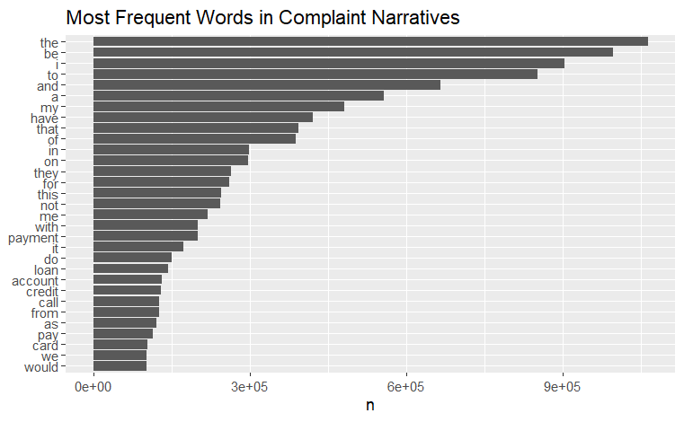

```r
data_token %>%
  count(word, sort = TRUE) %>%
  filter(n > 100000) %>%
  mutate(word = reorder(word, n)) %>%
  ggplot(aes(n, word)) +
  geom_col() +
  labs(y = NULL, title = "Most Frequent Words in Complaint Narratives")
```

We remove common stop words that don’t carry meaningful information:

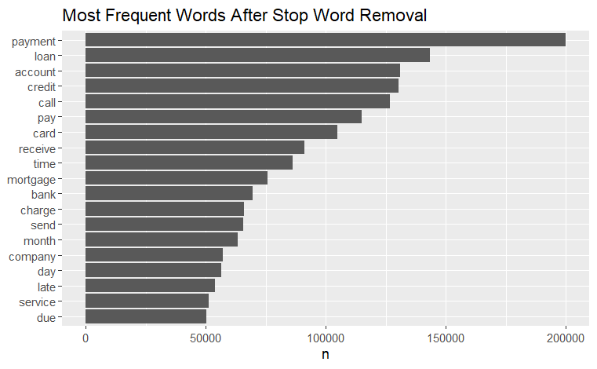

```r
data("stop_words")
data_token <- data_token %>%
  anti_join(stop_words)

# Re-examine word frequencies after removing stop words
data_token %>%
  count(word, sort = TRUE) %>%
  filter(n > 50000) %>%
  mutate(word = reorder(word, n)) %>%
  ggplot(aes(n, word)) +
  geom_col() +
  labs(y = NULL, title = "Most Frequent Words After Stop Word Removal")
```

# 4. Feature Engineering with TF-IDF

We select the top 20 words as features and compute TF-IDF (Term Frequency-Inverse Document Frequency) to identify words that are important to specific complaints:

```r
chosen_features <- data_token %>%
  count(word, sort = TRUE) %>% pull(word) %>% .[1:20]

tf_idf_data <- data_token %>%
  count(word, id_number, sort=TRUE) %>%
  bind_tf_idf(word, id_number, n) %>%
  arrange(desc(tf_idf))

# Create a wide format dataset with TF-IDF values
tf_idf_data_long <- tf_idf_data %>%
  filter(word %in% chosen_features) %>%
  select(word, id_number, tf_idf) %>%
  pivot_wider(id_cols = id_number, names_from = word, values_from = tf_idf, values_fill = 0.0)
```

# 5. Preparing Data for Machine Learning

We combine the TF-IDF features with the product labels:

```r
final_train_data <- train_data %>%
  select(id_number, Product) %>%
  left_join(tf_idf_data_long) %>%
  select(!id_number) %>%
  mutate(across(!Product, ~replace_na(., 0.0)))
```

# 6. Model Training with Random Forest

We split the data and train a Random Forest classifier:

```r
set.seed(123)
data_split <- initial_split(final_train_data, prop = 0.8, strata = Product)
training_data <- training(data_split)
testing_data  <- testing(data_split)

# Define the recipe for preprocessing
rf_recipe <- recipe(Product ~ ., data = training_data) %>%
  step_impute_mean()

# Specify the Random Forest model
rf_spec <- rand_forest(
  mtry = 5,       # Number of variables randomly sampled as candidates at each split
  trees = 500,    # Number of trees in the forest
  min_n = 5       # Minimum number of data points in a node
) %>%
  set_engine("ranger", importance = "impurity") %>%
  set_mode("classification")

# Create workflow and train the model
rf_workflow <- workflow() %>%
  add_recipe(rf_recipe) %>%
  add_model(rf_spec)

rf_fit <- rf_workflow %>%
  fit(data = training_data)
```

#7. Model Evaluation Finally, we evaluate the model’s performance on the testing set:

```r
# Generate predictions
rf_preds <- predict(rf_fit, testing_data) %>%
  bind_cols(testing_data)

# Calculate performance metrics
metrics <- rf_preds %>%
  mutate(
    Product = factor(Product),
    .pred_class = factor(.pred_class)
  ) %>%
  metrics(truth = Product, estimate = .pred_class)

# Create confusion matrix
conf_mat <- rf_preds %>%
  mutate(
    Product = factor(Product),
    .pred_class = factor(.pred_class)
  ) %>%
  conf_mat(truth = Product, estimate = .pred_class)

print(metrics)
```

| .metric | .estimator | .estimate |
| --- | --- | --- |
| accuracy | multiclass | 0.8110024 |
| kap | multiclass | 0.7182332 |

```r
print(conf_mat)
```

```
                             Truth
Prediction                    Credit card or prepaid card Mortgage
  Credit card or prepaid card                        7277      311
  Mortgage                                            159     5109
  Student loan                                         40      532
  Vehicle loan or lease                               183      240
                             Truth
Prediction                    Student loan Vehicle loan or lease
  Credit card or prepaid card          209                   474
  Mortgage                             313                   306
  Student loan                        1712                   409
  Vehicle loan or lease                263                   659
```

# Summary

- This analysis demonstrates a complete text classification pipeline:
- Text preprocessing and tokenization
- Feature engineering using TF-IDF
- Machine learning model training with Random Forest
- Model evaluation and performance metrics

The approach can be extended by experimenting with different feature selection methods, trying alternative algorithms, or incorporating more sophisticated text representation techniques like word embeddings.